# Hypothesis Testing

** GO BACK AND LOOK AT CORRELATION OF TIME BETWEEN LEARNING AND TESTING PHASE ** CALCULATE ANOVA EFFECT SIZES

## Study 1: Regular Order (Linear Model - then - Triangular Model)

### H1: The scaffolds function differently, and will significantly change the task completion time for unconventional graphs.

*The data largely support this hypothesis. Significant between group differences were found for the learning phase of the triangular model task, though not for the testing phase. The combined completion times (learning + testing phase) were significantly different by group, with the interactive depiction group finishing fastest, followed by the static depiction, data description, no scaffold and finally the visual element description group.*

#### a) Does response time on the triangular model task differ significantly between scaffold groups?

[figure not shown]

```
w.exp$condition: 0
     nbr.val     nbr.null       nbr.na          min          max        range          sum       median
  29.0000000    0.0000000    0.0000000    3.1400000   19.1100000   15.9700000  304.9500000   10.6200000
        mean      SE.mean CI.mean.0.95          var      std.dev     coef.var
  10.5155172    0.6819036    1.3968162   13.4847828    3.6721632    0.3492138
----------------------------------------------------------------------------------
w.exp$condition: 1
     nbr.val     nbr.null       nbr.na          min          max        range          sum       median
  31.0000000    0.0000000    0.0000000    7.5300000   26.8200000   19.2900000  363.8800000   10.8400000
        mean      SE.mean CI.mean.0.95          var      std.dev     coef.var
  11.7380645    0.7170494    1.4644103   15.9389561    3.9923622    0.3401210
----------------------------------------------------------------------------------
w.exp$condition: 2
     nbr.val     nbr.null       nbr.na          min          max        range          sum       median
  30.0000000    0.0000000    0.0000000    5.1700000   18.1200000   12.9500000  297.1400000    9.4750000
        mean      SE.mean CI.mean.0.95          var      std.dev     coef.var
   9.9046667    0.5537574    1.1325611    9.1994189    3.0330544    0.3062248
----------------------------------------------------------------------------------
w.exp$condition: 3
     nbr.val     nbr.null       nbr.na          min          max        range          sum       median
  30.0000000    0.0000000    0.0000000    5.3900000   20.7000000   15.3100000  294.0800000    9.3700000
        mean      SE.mean CI.mean.0.95          var      std.dev     coef.var
   9.8026667    0.5670218    1.1596899    9.6454133    3.1057066    0.3168226
----------------------------------------------------------------------------------
w.exp$condition: 4
     nbr.val     nbr.null       nbr.na          min          max        range          sum       median
  45.0000000    0.0000000    0.0000000    2.3700000   15.3900000   13.0200000  419.4400000    9.1600000
        mean      SE.mean CI.mean.0.95          var      std.dev     coef.var
   9.3208889    0.3647240    0.7350530    5.9860628    2.4466432    0.2624903
----------------------------------------------------------------------------------
w.exp$condition: e0
     nbr.val     nbr.null       nbr.na          min          max        range          sum       median
   3.0000000    0.0000000    0.0000000    7.8700000   12.5600000    4.6900000   32.6300000   12.2000000
        mean      SE.mean CI.mean.0.95          var      std.dev     coef.var
  10.8766667    1.5069211    6.4837581    6.8124333    2.6100639    0.2399691
----------------------------------------------------------------------------------
w.exp$condition: e4
     nbr.val     nbr.null       nbr.na          min          max        range          sum       median
   3.0000000    0.0000000    0.0000000    7.7900000    8.8100000    1.0200000   24.4400000    7.8400000
        mean      SE.mean CI.mean.0.95          var      std.dev     coef.var
   8.1466667    0.3319806    1.4283972    0.3306333    0.5750072    0.0705819
```

[output not shown]

#### b) Does response time on the triangular model task (learning phase) differ significantly between scaffold groups?

> During the triangular model task, participants in experimental groups 1 - 4 saw the graph scaffold while answering the first 5 questions, after which they answered 10 more questions without the scaffold. (Participants in group 0 – control – saw no scaffold). As the scaffolds contained information presented in different ways, we expect this will result in different completion times for the learning phase of the task.  
> **Yes, the mean response times for the learning phase (first 5 questions with scaffold) of the triangular model task differed significantly by scaffold group, F(1.163) = 12.17, p < 0.001. The longest fastest completion time was group 4 (interactive depiction) (M = 3.01 minutes, SD = 0.98), while the longest completion time was group 1 (visual element description) (M = 4.37 minutes, SD = 1.66), longer than the control (no scaffold) condition (M = 3.72 minutes, SD = 1.83).**

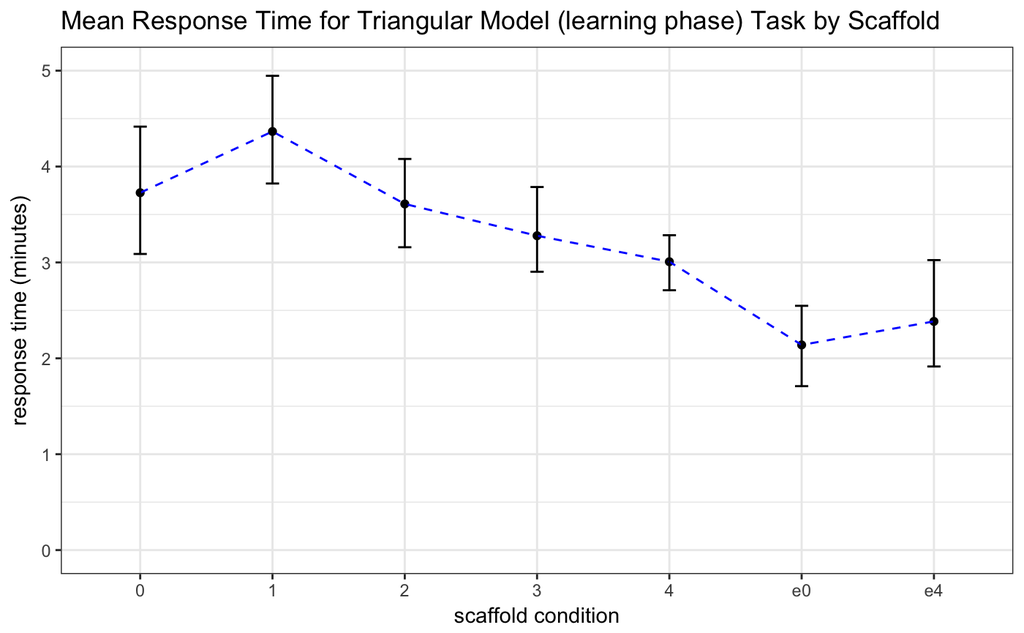

```
w.exp$condition: 0
     nbr.val     nbr.null       nbr.na          min          max        range          sum       median
  29.0000000    0.0000000    0.0000000    0.7788667    8.0880667    7.3092000  108.0863667    3.4191167
        mean      SE.mean CI.mean.0.95          var      std.dev     coef.var
   3.7271161    0.3404744    0.6974303    3.3617625    1.8335110    0.4919383
----------------------------------------------------------------------------------
w.exp$condition: 1
     nbr.val     nbr.null       nbr.na          min          max        range          sum       median
  31.0000000    0.0000000    0.0000000    1.5675333   10.5030833    8.9355500  135.3423167    3.9553000
        mean      SE.mean CI.mean.0.95          var      std.dev     coef.var
   4.3658812    0.2990458    0.6107330    2.7722802    1.6650166    0.3813701
----------------------------------------------------------------------------------
w.exp$condition: 2
     nbr.val     nbr.null       nbr.na          min          max        range          sum       median
  30.0000000    0.0000000    0.0000000    1.7573500    6.5815167    4.8241667  108.2990167    3.5781417
        mean      SE.mean CI.mean.0.95          var      std.dev     coef.var
   3.6099672    0.2307699    0.4719775    1.5976430    1.2639790    0.3501359
----------------------------------------------------------------------------------
w.exp$condition: 3
     nbr.val     nbr.null       nbr.na          min          max        range          sum       median
  30.0000000    0.0000000    0.0000000    1.8567000    8.6666833    6.8099833   98.3562333    3.0459333
        mean      SE.mean CI.mean.0.95          var      std.dev     coef.var
   3.2785411    0.2337805    0.4781348    1.6395999    1.2804686    0.3905605
----------------------------------------------------------------------------------
w.exp$condition: 4
     nbr.val     nbr.null       nbr.na          min          max        range          sum       median
  45.0000000    0.0000000    0.0000000    0.7954000    6.2483000    5.4529000  135.3457500    2.9858500
        mean      SE.mean CI.mean.0.95          var      std.dev     coef.var
   3.0076833    0.1460086    0.2942610    0.9593333    0.9794556    0.3256512
```

```
w.exp$condition coerced to factor.
```

```
Levene's Test for Homogeneity of Variance (center = median)
       Df F value  Pr(>F)
group   4  3.1932 0.01483 *
      160
---
Signif. codes:  0 ‘***’ 0.001 ‘**’ 0.01 ‘*’ 0.05 ‘.’ 0.1 ‘ ’ 1
             Df Sum Sq Mean Sq F value   Pr(>F)
condition     1   24.3  24.342   12.17 0.000626 ***
Residuals   163  326.1   2.001
---
Signif. codes:  0 ‘***’ 0.001 ‘**’ 0.01 ‘*’ 0.05 ‘.’ 0.1 ‘ ’ 1

Call:
aov(formula = TS_T_M ~ condition, data = w.exp)

Residuals:
    Min      1Q  Median      3Q     Max
-3.3452 -0.8461 -0.1037  0.6263  6.6423

Coefficients:
            Estimate Std. Error t value Pr(>|t|)
(Intercept)  4.12408    0.19850  20.777  < 2e-16 ***
condition   -0.26328    0.07548  -3.488 0.000626 ***
---
Signif. codes:  0 ‘***’ 0.001 ‘**’ 0.01 ‘*’ 0.05 ‘.’ 0.1 ‘ ’ 1

Residual standard error: 1.415 on 163 degrees of freedom
Multiple R-squared:  0.06945,   Adjusted R-squared:  0.06374
F-statistic: 12.17 on 1 and 163 DF,  p-value: 0.0006259
```

.. Levene’s IS signficant… therefore SHOULD use robust methods… 1 way independent means ANOVA signficant at p < .001. Multiple R-squared = 0.07, therefore eta squared = 0.07 therefore effect size R = sqrt(0.07) = 0.26 a small effect.

#### c) Does response time on the triangular model task (testing phase) differ significantly between scaffold groups?

> After answering the first five questions (learning phase) with scaffolds, participants continued on to answer 10 progressively more complex questions without scaffolds. Without scaffold assistance, the graphs viewed by each group were identical. Although this means the information processing demands are the same across groups, we expect the completion time for the testing phase will differ significantly based on how well the scaffold facilitated the participant’s learning of the graph system. **The mean completion time for the testing phase of the triangular model task did not differ significantly by scaffold group, F(1,163) = 1.99, p = 0.16, r = 0.11.**

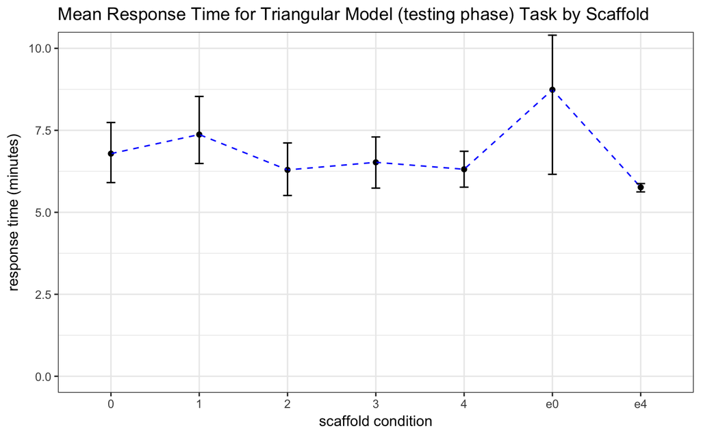

```
w.exp$condition: 0
     nbr.val     nbr.null       nbr.na          min          max        range          sum       median
  29.0000000    0.0000000    0.0000000    2.3592333   13.1108500   10.7516167  196.8823833    6.2431167
        mean      SE.mean CI.mean.0.95          var      std.dev     coef.var
   6.7890477    0.4954459    1.0148748    7.1185315    2.6680576    0.3929944
----------------------------------------------------------------------------------
w.exp$condition: 1
     nbr.val     nbr.null       nbr.na          min          max        range          sum       median
  31.0000000    0.0000000    0.0000000    3.9030833   20.0969167   16.1938333  228.5187167    6.4965500
        mean      SE.mean CI.mean.0.95          var      std.dev     coef.var
   7.3715715    0.5534813    1.1303595    9.4965864    3.0816532    0.4180456
----------------------------------------------------------------------------------
w.exp$condition: 2
     nbr.val     nbr.null       nbr.na          min          max        range          sum       median
  30.0000000    0.0000000    0.0000000    2.7404333   12.2610833    9.5206500  188.8055167    6.0344167
        mean      SE.mean CI.mean.0.95          var      std.dev     coef.var
   6.2935172    0.3979142    0.8138259    4.7500712    2.1794658    0.3463033
----------------------------------------------------------------------------------
w.exp$condition: 3
     nbr.val     nbr.null       nbr.na          min          max        range          sum       median
  30.0000000    0.0000000    0.0000000    2.9962500   12.0365667    9.0403167  195.7237167    5.7579250
        mean      SE.mean CI.mean.0.95          var      std.dev     coef.var
   6.5241239    0.4192879    0.8575400    5.2740702    2.2965344    0.3520066
----------------------------------------------------------------------------------
w.exp$condition: 4
     nbr.val     nbr.null       nbr.na          min          max        range          sum       median
  45.0000000    0.0000000    0.0000000    1.5733167   10.9093333    9.3360167  284.0791167    6.3120500
        mean      SE.mean CI.mean.0.95          var      std.dev     coef.var
   6.3128693    0.2874720    0.5793618    3.7188073    1.9284209    0.3054746
```

```
w.exp$condition coerced to factor.
```

```
Levene's Test for Homogeneity of Variance (center = median)
       Df F value Pr(>F)
group   4  0.3561 0.8395
      160
             Df Sum Sq Mean Sq F value Pr(>F)
condition     1   11.6  11.643   1.991   0.16
Residuals   163  952.9   5.846

Call:
aov(formula = TT_T_M ~ condition, data = w.exp)

Residuals:
    Min      1Q  Median      3Q     Max
-4.7271 -1.4024 -0.4507  0.9176 13.2503

Coefficients:
            Estimate Std. Error t value Pr(>|t|)
(Intercept)   7.0287     0.3393  20.716   <2e-16 ***
condition    -0.1821     0.1290  -1.411     0.16
---
Signif. codes:  0 ‘***’ 0.001 ‘**’ 0.01 ‘*’ 0.05 ‘.’ 0.1 ‘ ’ 1

Residual standard error: 2.418 on 163 degrees of freedom
Multiple R-squared:  0.01207,   Adjusted R-squared:  0.006009
F-statistic: 1.991 on 1 and 163 DF,  p-value: 0.1601
```

Levene’s is nonsignificant, therefore run 1 way independent means ANOVA, which is not signficant at p < 0.001. Multiple R-squared = 0.012, therefore eta-squared = 0.012 therefore effect size r = sqrt (0.012) = 0.11, a small effect.

#### d) Does response time on the drawing task (testing phase) differ significantly between scaffold groups?

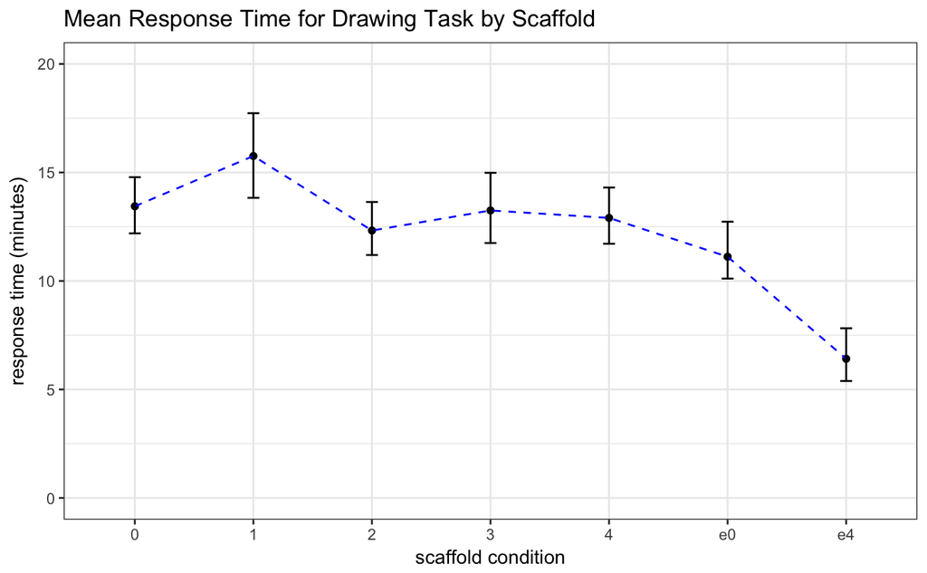

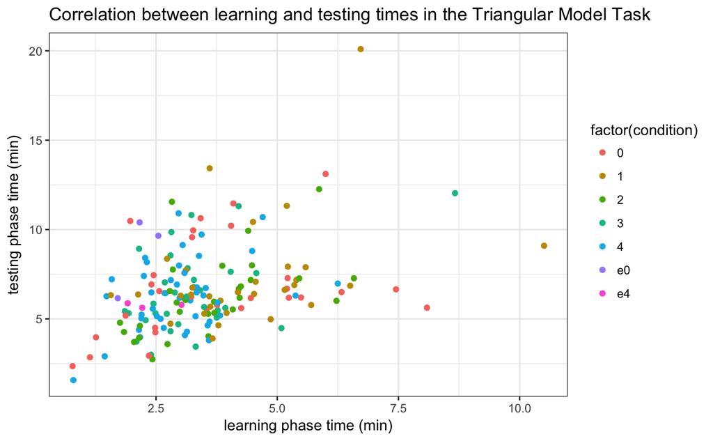